# R Readiness Completed

Carlos Mercado

11/11/2020

## Congratulations!

You’ve made it to the end of the R Readiness course. Here is the answer key for your reference.

Remember, you aren’t going to remember all this syntax long-term (I know I don’t!) but you’ve proven the ability to get data, research the syntax, read documentation, and put together a script that’s reproducible and outputs summaries and visualizations.

### Lesson 0

In Lesson 0 you learned: that R Projects allow your code to work across any computer (i.e. you don’t have to worry about C:/Users/cmercado/Documents…) instead, the R Project lets you reference files *relative* to whatever folder the R Project is in.

This aids **reproducibility**.

### Lesson 1

In lesson 1 you learned:

1. How to read an excel file.
2. How to filter to only a certain set of columns.
3. Change column names programmatically.
4. Inspect your data.
5. Write your updated dataset to a new csv file.

Library loads add-on packages like readxl. The readxl package has a function that allows R to read Excel files.

- Google search: how to read excel in r
- Result: https://readxl.tidyverse.org/

Using the read_excel function, we pull our data from our Data folder.

```
## list.files() confirms that we have a data folder in this R Project:
```

```
##  [1] "Data"                            "Individual Reviews"
##  [3] "Lesson-HTMLs"                    "Lessons"
##  [5] "progress_data.csv"               "R-Readiness-Complete.html"
##  [7] "R-Readiness-NoCode-Complete.Rmd" "R Readiness-NoCode-Complete.Rmd"
##  [9] "R Readiness Complete.Rmd"        "R_Readiness.Rproj"
## [11] "Readiness_Course"                "Readiness_Course.zip"
## [13] "Rubric.docx"
```

##### 1. Load Excel File

##### 2. Identify desired columns and filter by them

- Google search: how to select only certain columns in r
- Result: https://stackoverflow.com/questions/10085806/

##### 3. Change Column Names

- method 1: copy into a new column and then just drop the old one
- Google search: copy a column in r
- Result: https://stackoverflow.com/questions/22030252
- Google search: erase column in r
- Result: https://stackoverflow.com/questions/6286313
- method 2: rename the column
- Google search: rename a column in r
- Result: https://stackoverflow.com/questions/7531868

##### 4. Inspect data

- Google search: see first few rows of data in r
- Result: https://stackoverflow.com/questions/2667673

```
## # A tibble: 6 x 8
##   `Date Of Stop`      SubAgency Accident `Personal Injur~ `Property Damag~
##   <dttm>              <chr>     <chr>    <chr>            <chr>
## 1 2018-04-12 00:00:00 3rd Dist~ No       No               No
## 2 2016-11-10 00:00:00 4th Dist~ No       No               No
## 3 2018-01-31 00:00:00 2nd Dist~ No       No               No
## 4 2015-12-08 00:00:00 6th Dist~ No       No               No
## 5 2016-09-14 00:00:00 4th Dist~ No       No               No
## 6 2016-05-15 00:00:00 2nd Dist~ No       No               No
## # ... with 3 more variables: Fatal <chr>, Alcohol <chr>, `Vehicle
## #   Year` <chr>
```

##### 5. Write to a new CSV

- Google search: write data to csv in r
- Result: https://datatofish.com/export-dataframe-to-csv-in-r/

### Lesson 2

In lesson 2 you learned:

1. How to read your csv file.
2. How to check the class of your columns of data.
3. How to get summary statistics from your data.
4. How different classes affect the summary statistics you get.

##### 1. Read CSV

- Google search: read csv in r
- Result: https://swcarpentry.github.io/r-novice-inflammation/11-supp-read-write-csv/

##### 2. Check out your column classes

- Google search: get column classes in r
- Result: https://stackoverflow.com/questions/10661159
- method 1: the L (list) apply function

```
## $X
## [1] "integer"
##
## $Date.Of.Stop
## [1] "factor"
##
## $SubAgency
## [1] "factor"
##
## $Accident
## [1] "factor"
##
## $Personal.Injury
## [1] "factor"
##
## $Property.Damage
## [1] "factor"
##
## $Fatal
## [1] "factor"
##
## $Alcohol
## [1] "factor"
##
## $Vehicle.Year
## [1] "integer"
```

- method 2: the structure function

```
## 'data.frame':    50000 obs. of  9 variables:
##  $ X              : int  1 2 3 4 5 6 7 8 9 10 ...
##  $ Date.Of.Stop   : Factor w/ 2753 levels "2012-01-01","2012-01-02",..: 2290 1772 2219 1437 1715 1593 1028 2155 2278 2378 ...
##  $ SubAgency      : Factor w/ 7 levels "1st District, Rockville",..: 3 4 2 6 4 2 3 2 4 2 ...
##  $ Accident       : Factor w/ 2 levels "No","Yes": 1 1 1 1 1 1 1 1 1 1 ...
##  $ Personal.Injury: Factor w/ 2 levels "No","Yes": 1 1 1 1 1 1 1 1 1 1 ...
##  $ Property.Damage: Factor w/ 2 levels "No","Yes": 1 1 1 1 1 1 2 1 1 1 ...
##  $ Fatal          : Factor w/ 2 levels "No","Yes": 1 1 1 1 1 1 1 1 1 1 ...
##  $ Alcohol        : Factor w/ 2 levels "No","Yes": 1 1 1 1 1 1 1 1 1 1 ...
##  $ Vehicle.Year   : int  2010 2010 1999 2004 2012 2003 2010 2012 2013 2004 ...
```

##### 3. How to get summary statistics for your data

- Google search: get summary statistics of my data in r
- Result: https://www.statmethods.net/stats/descriptives.html
- method 1: use a function like mean on all the columns

```
## This is going to spit out arrows and NAs because you can't
##         get the average on non-numbers
```

```
##               X    Date.Of.Stop       SubAgency        Accident
##       25000.500              NA              NA              NA
## Personal.Injury Property.Damage           Fatal         Alcohol
##              NA              NA              NA              NA
##    Vehicle.Year
##        2006.186
```

- method 2: use a general function like summary

```
##        X             Date.Of.Stop
##  Min.   :    1   2015-03-16:   47
##  1st Qu.:12501   2015-01-20:   45
##  Median :25001   2015-02-11:   45
##  Mean   :25001   2014-05-14:   44
##  3rd Qu.:37500   2018-01-23:   43
##  Max.   :50000   2018-02-21:   43
##                  (Other)   :49733
##                                            SubAgency     Accident
##  1st District, Rockville                        : 6018   No :48822
##  2nd District, Bethesda                         : 8167   Yes: 1178
##  3rd District, Silver Spring                    : 9667
##  4th District, Wheaton                          :12328
##  5th District, Germantown                       : 5743
##  6th District, Gaithersburg / Montgomery Village: 6477
##  Headquarters and Special Operations            : 1600
##  Personal.Injury Property.Damage Fatal       Alcohol      Vehicle.Year
##  No :49434       No :49038       No :49993   No :49916   Min.   :   0
##  Yes:  566       Yes:  962       Yes:    7   Yes:   84   1st Qu.:2002
##                                                          Median :2007
##                                                          Mean   :2006
##                                                          3rd Qu.:2011
##                                                          Max.   :9999
##                                                          NA's   :358
```

##### 4. How different classes can affect summary statistics

Notice how before it would count the frequency of your text column values but now it just tells you how many there are total, but no counts.

```
##        X         Date.Of.Stop        SubAgency           Accident
##  Min.   :    1   Length:50000       Length:50000       Length:50000
##  1st Qu.:12501   Class :character   Class :character   Class :character
##  Median :25001   Mode  :character   Mode  :character   Mode  :character
##  Mean   :25001
##  3rd Qu.:37500
##  Max.   :50000
##
##  Personal.Injury    Property.Damage       Fatal
##  Length:50000       Length:50000       Length:50000
##  Class :character   Class :character   Class :character
##  Mode  :character   Mode  :character   Mode  :character
##
##
##
##
##    Alcohol           Vehicle.Year
##  Length:50000       Min.   :   0
##  Class :character   1st Qu.:2002
##  Mode  :character   Median :2007
##                     Mean   :2006
##                     3rd Qu.:2011
##                     Max.   :9999
##                     NA's   :358
```

### Lesson 3

In lesson 3 you learned:

1. Excluding rows with NAs
2. subsetting to only rows that meet a condition
3. Creating a histogram
4. Cleaning data through bottom and top coding of data values
5. Creating a plot with custom titles and captions
6. Stretch: extract month from a date for visualizing.

##### 1. Exclude rows with NAs

- Google search: exclude rows with na in r
- Result: https://stackoverflow.com/questions/4862178

- Google search: only keep certain rows in r
- Result: https://stackoverflow.com/questions/19200188/

##### 3. Create a histogram

- Google search: create histogram in r
- Result: https://www.datamentor.io/r-programming/histogram/

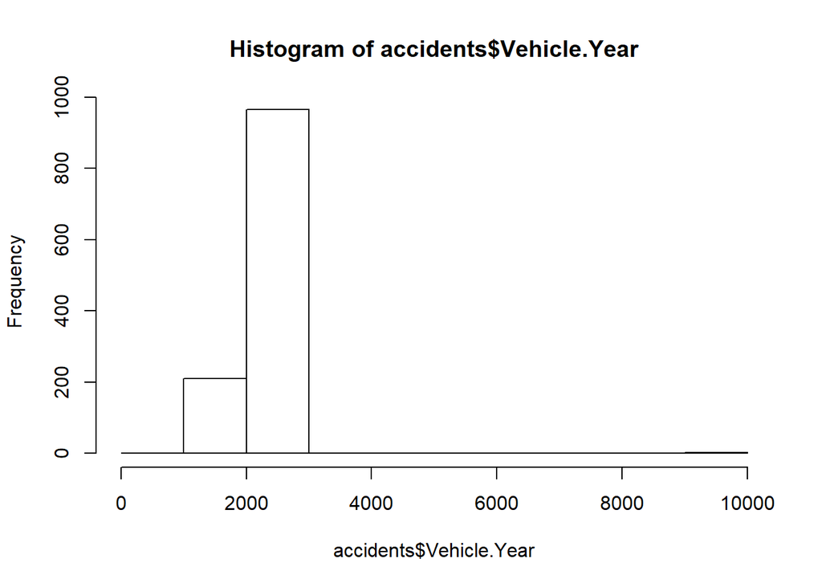

##### 4. Clean up data

- Google search: change data value in r
- Result: https://rstudio-education.github.io/hopr/modify.html

##### 5. Create a better histogram

- Google search: create histogram in r
- Result: https://www.datamentor.io/r-programming/histogram/

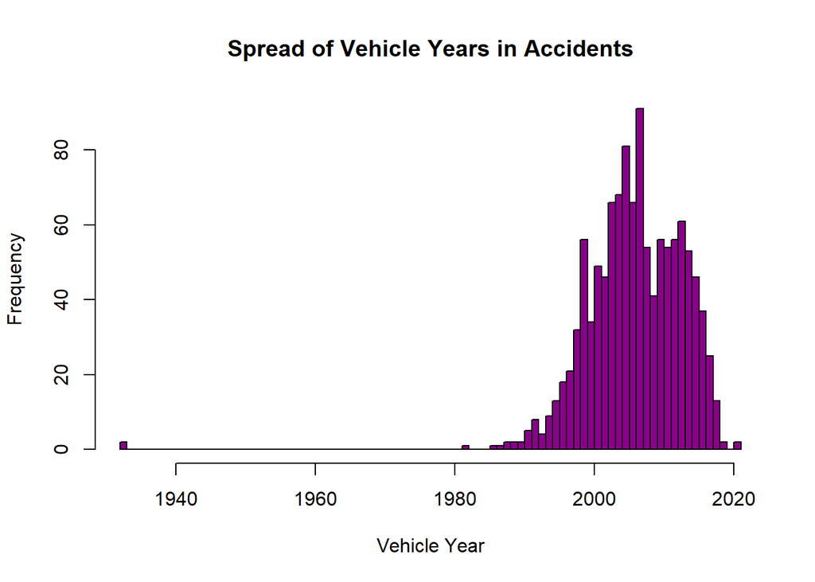

##### 6. Stretch: Extracting month for visualization

- Google search: get month from date in r
- Result: https://stackoverflow.com/questions/22603847

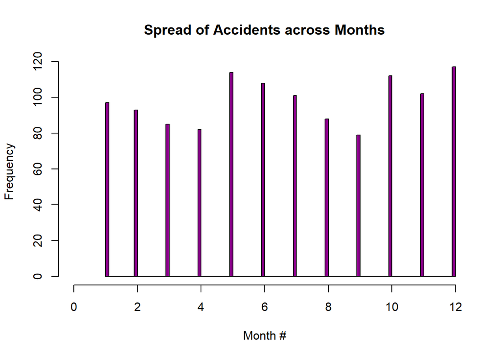

### Lesson 4

Lesson 4 is definitely the hardest lesson, but with enough googling the answers are available.

In lesson 4, you learned:

1. how to create a new variable aggregating accidents to Month-Year.
2. summarize data to this month-year group, specifically: # of accidents, # of Fatal, and # of Alcohol involved.
3. Plot it using ggplot2, a highly customizable data visualization package.

##### 1. Extract Month and Year

- Google search: get month and year from date in r
- Result: https://stackoverflow.com/questions/37704212

The %Y-%m-01 format, allows the *class* to remain Date. This is very useful for plotting purposes as it can be very crowded to have text as the x axis.

##### 2. summarize data by group

- Google search: summarize data by group in r
- Result: https://stackoverflow.com/questions/9847054

Quick note. A LOT of R programmers love to use dplyr as it is a robust “dialect” of R with hundreds of its own functions and use cases. If you can’t find a solution to something, try adding “dplyr” to your searches. Also, you’ll note that the google result provided here was *not* the top result. Probably 80% of the time the top result will be useful to you, but I find myself biased to looking for stackoverflow links specifically because they tend to have lots of options and lots of explanation of what’s going on and easy to understand templates.

```
## # A tibble: 91 x 4
##    Month_Year Num_Accidents Num_Fatal Num_Alcohol
##    <date>             <int>     <int>       <int>
##  1 2012-01-01             7         0           0
##  2 2012-02-01            10         0           0
##  3 2012-03-01             7         0           0
##  4 2012-04-01             5         0           0
##  5 2012-05-01            11         0           0
##  6 2012-06-01             6         0           0
##  7 2012-07-01             7         0           0
##  8 2012-08-01            10         0           0
##  9 2012-09-01            11         0           0
## 10 2012-10-01            10         0           0
## # ... with 81 more rows
```

##### 3. Plot using ggplot2

- Google search: make ggplot2 with color and size in r
- Result: http://www.sthda.com/english/wiki/ggplot2-scatter-plots-quick-start-guide-r-software-and-data-visualization

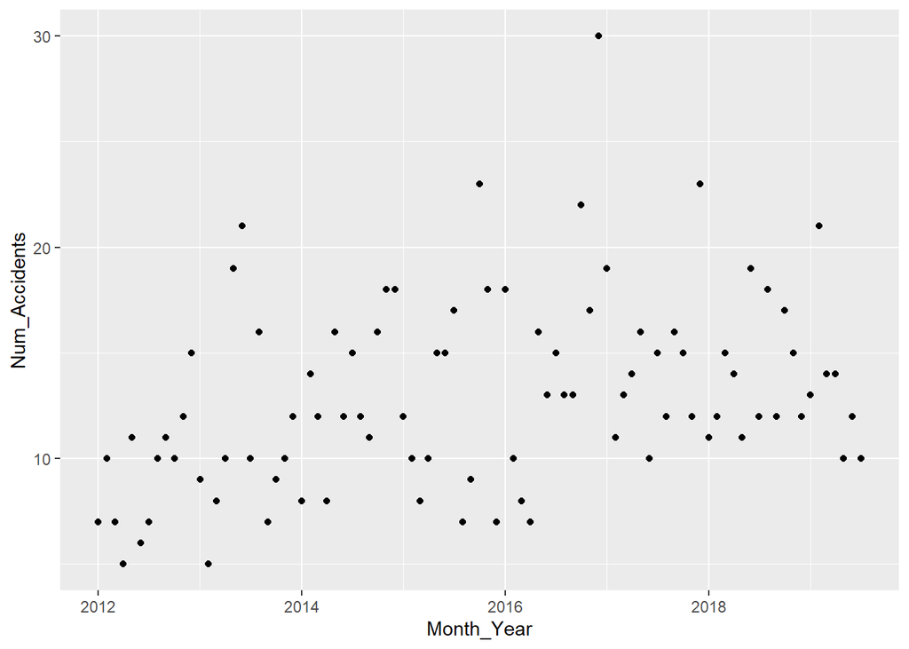

Going through the guide you can make increasingly complex plots.

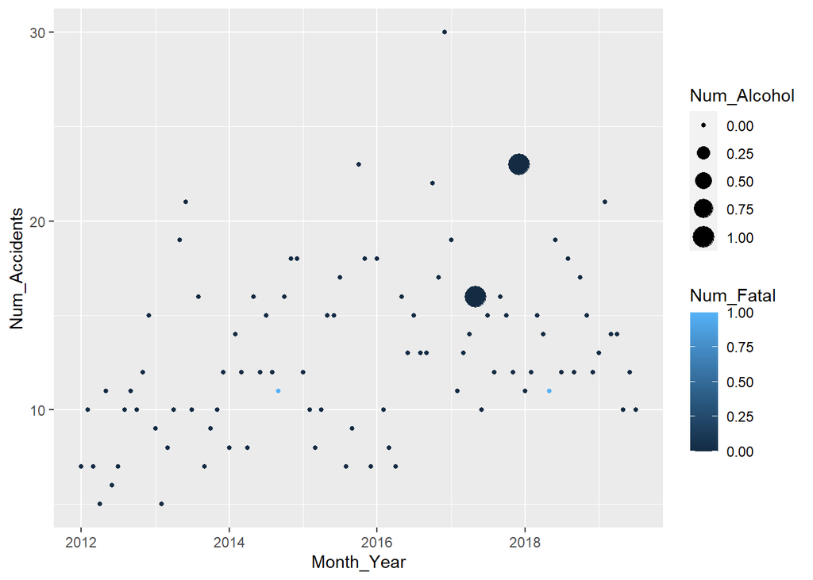

Forcing categories can make the legends cleaner too. Here’s a basic example:

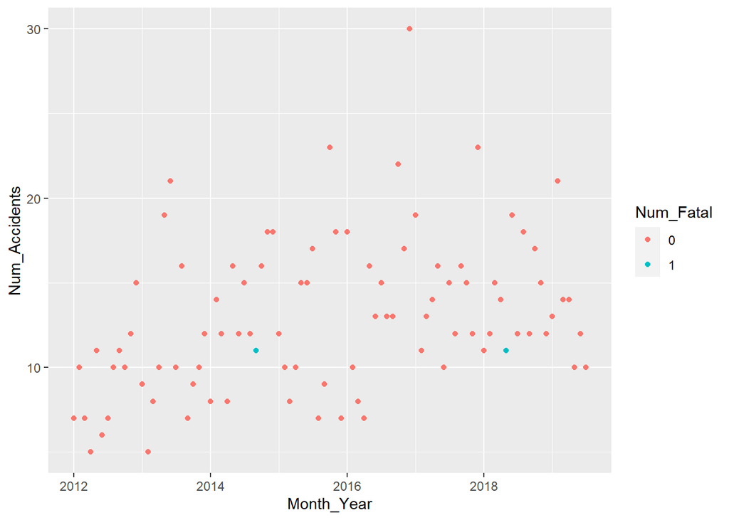

Now of course, making highly aesthetic plots may involve doing deeper research into the specific packages or doing additional variable creation (e.g. insted of number of fatal, just Yes/No if there is a fatal in that month).

You can always google things like “good ggplot2 visual with code in r” and see what kind of nice examples you find.

Here’s a great resource that I use!

http://r-statistics.co/Top50-Ggplot2-Visualizations-MasterList-R-Code.html